# Paleomagnetic Field Tests for 'Possible Eoarchean records of the geomagnetic field preserved in the Isua Supracrustal Belt, southern west Greenland'

This notebook outlines the analyses used for the pseudo-baked contact tests, fold test and reversal tests outlined in our paper. All of our data were analysed using PMagPy, and details of each approach can be found in the [PMagPy cookbook](https://pmagpy.github.io/PmagPy-docs/intro.html)

To start with, make sure you have everything imported to run PMagPy:

```python
import pmagpy.pmag as pmag
import pmagpy.pmagplotlib as pmagplotlib
import pmagpy.ipmag as ipmag
import matplotlib.pyplot as plt # our plotting buddy
from pmagpy import convert_2_magic as convert
import numpy as np # the fabulous NumPy package
import pandas as pd # and of course Pandas
has_basemap, Basemap = pmag.import_basemap()
has_cartopy, Cartopy = pmag.import_cartopy()
from IPython.display import Image
%matplotlib inline
```

# Passed Pseudo-Baked Contact Tests

In this section, we will look at the data for our 'pseudo' baked contact tests. We sampled banded iron formation (BIF) intruded by Ameralik dykes that were emplaced 3.26-3.5 Ga.  
However, the dykes were metamorphosed at 2.85 Ga, overprinting their magnetization so we do not use them in our analysis. Therefore we compare 'baked BIF' (close to the intrusion) with 'unbaked BIF' (far from the intrusion) to determine whether the paleomagnetic directions are sufficiently different to verify that the unbaked BIF still retains its 3.69 Ga remanence prior to dyke emplacement.

For each test, there are two .txt files named 'sitename_unbaked.txt' and 'sitename_baked.txt' that contain the declinations and inclinations from each site.

## Site 6A

Firstly, the unbaked and baked data are loaded and named 'directions_A' and 'directions_B' respectively. We then calculate the fisher mean and alpha95 value (shown by the stars and large circles, respectively) and plot these along with the directional data for each specimen in red for baked directions and blue for unbaked directions.

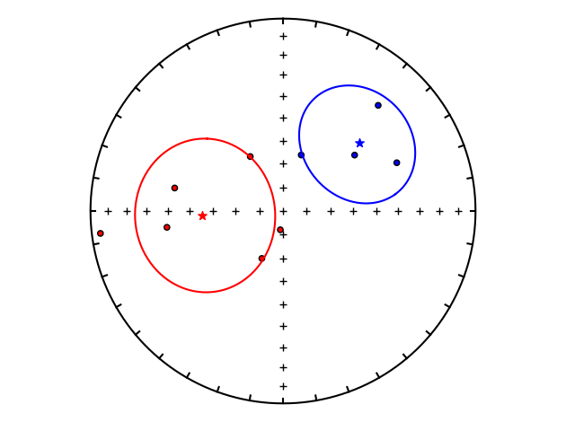

```python
directions_A=np.loadtxt('6A_unbaked.txt', delimiter = ',').transpose()
directions_B=np.loadtxt('6A_baked.txt', delimiter = ',').transpose()
decA=directions_A[0]
incA=directions_A[1]
decB=directions_B[0]
incB=directions_B[1]
#calculate Fisher mean and alpha 95
fisherA=ipmag.fisher_mean(dec=decA,inc=incA)
fisherB=ipmag.fisher_mean(dec=decB,inc=incB)
# plots stereonet of data
ipmag.plot_net(1)
directions_A=np.loadtxt('6A_unbaked.txt', delimiter = ',')
directions_B=np.loadtxt('6A_baked.txt', delimiter = ',')
ipmag.plot_di(di_block=directions_A,color='blue',edge='black')
ipmag.plot_di(di_block=directions_B,color='red',edge='black')
ipmag.plot_di_mean(dec=fisherA['dec'],inc=fisherA['inc'],a95=fisherA['alpha95'],\
                  marker='*',color='blue',markersize=50)
ipmag.plot_di_mean(dec=fisherB['dec'],inc=fisherB['inc'],a95=fisherB['alpha95'],\
                  marker='*',color='red',markersize=50)
```

Next, we check to see if the unbaked and baked directions are statistically similar using Watson's V test. For our pseudo-baked contact test to pass, the critical value of V (blude dashed line) must be less than Watson's V value for our data (green line). This means that the unbaked and baked directions are distinct to 95% confidence. So at site 6A, our pseudo-baked contact test passes.

```
Results of Watson V test:

Watson's V:           29.6
Critical value of V:  7.6
"Fail": Since V is greater than Vcrit, the two means can
be distinguished at the 95% confidence level.

M&M1990 classification:

Angle between data set means: 73.6
Critical angle for M&M1990:   36.6
```

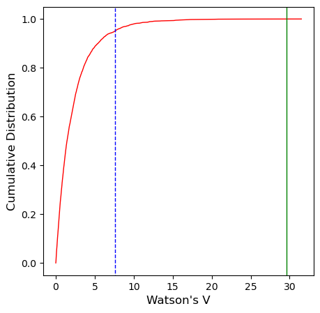

```
(0, 73.64821902900087, 36.56358510517804, '')
```

```python
directions_A=np.loadtxt('6A_unbaked.txt', delimiter = ',')
directions_B=np.loadtxt('6A_baked.txt', delimiter = ',')
# Watson V test
plt.figure(1,(5,5))
ipmag.common_mean_watson(directions_A,directions_B,plot='yes')
```

## Site C

Firstly, the unbaked and baked data are loaded and named 'directions_A' and 'directions_B' respectively. We then calculate the fisher mean and alpha95 value (shown by the stars and large circles, respectively) and plot these along with the directional data for each specimen in red for baked directions and blue for unbaked directions.

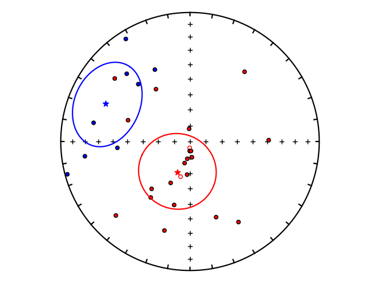

```python
directions_A=np.loadtxt('C_unbaked.txt', delimiter = ',').transpose()
directions_B=np.loadtxt('C_baked.txt', delimiter = ',').transpose()
decA=directions_A[0]
incA=directions_A[1]
decB=directions_B[0]
incB=directions_B[1]
#calculate Fisher mean and alpha 95
fisherA=ipmag.fisher_mean(dec=decA,inc=incA)
fisherB=ipmag.fisher_mean(dec=decB,inc=incB)
# plots stereonet of data
ipmag.plot_net(1)
directions_A=np.loadtxt('C_unbaked.txt', delimiter = ',')
directions_B=np.loadtxt('C_baked.txt', delimiter = ',')
ipmag.plot_di(di_block=directions_A,color='blue',edge='black')
ipmag.plot_di(di_block=directions_B,color='red',edge='black')
ipmag.plot_di_mean(dec=fisherA['dec'],inc=fisherA['inc'],a95=fisherA['alpha95'],\
                  marker='*',color='blue',markersize=50)
ipmag.plot_di_mean(dec=fisherB['dec'],inc=fisherB['inc'],a95=fisherB['alpha95'],\
                  marker='*',color='red',markersize=50)
```

Next, we check to see if the unbaked and baked directions are statistically similar using Watson's V test. For our pseudo-baked contact test to pass, the critical value of V (blude dashed line) must be less than Watson's V value for our data (green line). This means that the unbaked and baked directions are distinct to 95% confidence. So at site C, our pseudo-baked contact test passes.

```
Results of Watson V test:

Watson's V:           23.9
Critical value of V:  6.4
"Fail": Since V is greater than Vcrit, the two means can
be distinguished at the 95% confidence level.

M&M1990 classification:

Angle between data set means: 63.7
Critical angle for M&M1990:   32.5
```

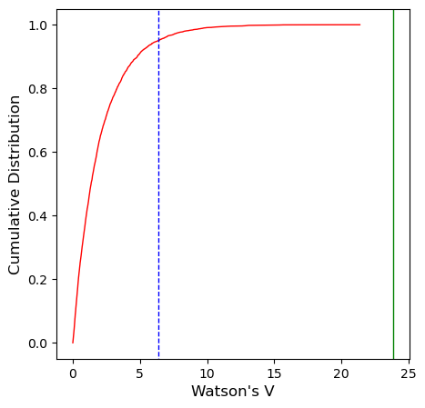

```
(0, 63.65969638538241, 32.53918413718622, '')
```

```python
directions_A=np.loadtxt('C_unbaked.txt', delimiter = ',')
directions_B=np.loadtxt('C_baked.txt', delimiter = ',')
plt.figure(1,(5,5))
ipmag.common_mean_watson(directions_A,directions_B,plot='yes')
```

## Site 8A/A

Firstly, the unbaked and baked data are loaded and named 'directions_A' and 'directions_B' respectively. We then calculate the fisher mean and alpha95 value (shown by the stars and large circles, respectively) and plot these along with the directional data for each specimen in red for baked directions and blue for unbaked directions.

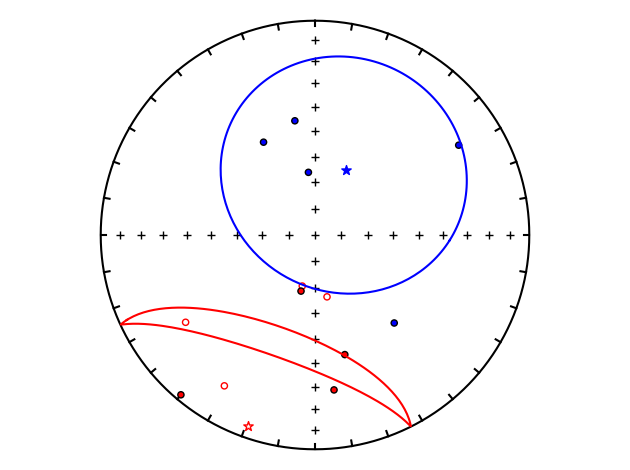

```python
directions_A=np.loadtxt('8A_A_unbaked.txt', delimiter = ',').transpose()
directions_B=np.loadtxt('8A_A_baked.txt', delimiter = ',').transpose()
decA=directions_A[0]
incA=directions_A[1]
decB=directions_B[0]
incB=directions_B[1]
#calculate Fisher mean and alpha 95
fisherA=ipmag.fisher_mean(dec=decA,inc=incA)
fisherB=ipmag.fisher_mean(dec=decB,inc=incB)
# plots stereonet of data
ipmag.plot_net(1)
directions_A=np.loadtxt('8A_A_unbaked.txt', delimiter = ',')
directions_B=np.loadtxt('8A_A_baked.txt', delimiter = ',')
ipmag.plot_di(di_block=directions_A,color='blue',edge='black')
ipmag.plot_di(di_block=directions_B,color='red',edge='black')
ipmag.plot_di_mean(dec=fisherA['dec'],inc=fisherA['inc'],a95=fisherA['alpha95'],\
                  marker='*',color='blue',markersize=50)
ipmag.plot_di_mean(dec=fisherB['dec'],inc=fisherB['inc'],a95=fisherB['alpha95'],\
                  marker='*',color='red',markersize=50)
```

Next, we check to see if the unbaked and baked directions are statistically similar using Watson's V test. For our pseudo-baked contact test to pass, the critical value of V (blude dashed line) must be less than Watson's V value for our data (green line). This means that the unbaked and baked directions are distinct to 95% confidence. So at site 8A/A, our pseudo-baked contact test passes.

```
Results of Watson V test:

Watson's V:           27.4
Critical value of V:  6.8
"Fail": Since V is greater than Vcrit, the two means can
be distinguished at the 95% confidence level.

M&M1990 classification:

Angle between data set means: 123.5
Critical angle for M&M1990:   59.3
```

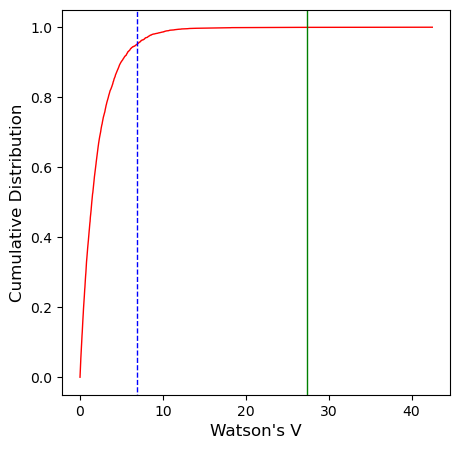

```
(0, 123.52483818795639, 59.32987363578838, '')
```

```python
directions_A=np.loadtxt('8A_A_unbaked.txt', delimiter = ',')
directions_B=np.loadtxt('8A_A_baked.txt', delimiter = ',')
plt.figure(1,(5,5))
ipmag.common_mean_watson(directions_A,directions_B,plot='yes')
```

## (Site D)

Firstly, the unbaked and baked data are loaded and named 'directions_A' and 'directions_B' respectively. We then calculate the fisher mean and alpha95 value (shown by the stars and large circles, respectively) and plot these along with the directional data for each specimen in red for baked directions and blue for unbaked directions.

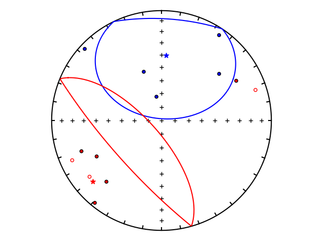

```python
directions_A=np.loadtxt('D_unbaked.txt', delimiter = ',').transpose()
directions_B=np.loadtxt('D_baked.txt', delimiter = ',').transpose()
decA=directions_A[0]
incA=directions_A[1]
decB=directions_B[0]
incB=directions_B[1]
#calculate Fisher mean and alpha 95
fisherA=ipmag.fisher_mean(dec=decA,inc=incA)
fisherB=ipmag.fisher_mean(dec=decB,inc=incB)
# plots stereonet of data
ipmag.plot_net(1)
directions_A=np.loadtxt('D_unbaked.txt', delimiter = ',')
directions_B=np.loadtxt('D_baked.txt', delimiter = ',')
ipmag.plot_di(di_block=directions_A,color='blue',edge='black')
ipmag.plot_di(di_block=directions_B,color='red',edge='black')
ipmag.plot_di_mean(dec=fisherA['dec'],inc=fisherA['inc'],a95=fisherA['alpha95'],\
                  marker='*',color='blue',markersize=50)
ipmag.plot_di_mean(dec=fisherB['dec'],inc=fisherB['inc'],a95=fisherB['alpha95'],\
                  marker='*',color='red',markersize=50)
```

Next, we check to see if the unbaked and baked directions are statistically similar using Watson's V test. For our pseudo-baked contact test to pass, the critical value of V (blude dashed line) must be less than Watson's V value for our data (green line). This means that the unbaked and baked directions are distinct to 95% confidence. So at site D, our pseudo-baked contact test techincally passes. However, given the very large directional uncertainty and overlapping $\alpha_{95}$ values, Site D and our thermal models that show the unbaked region was likey thermally influenced by the dyke, Site D is not considered in further analysis.

```
Results of Watson V test:

Watson's V:           14.0
Critical value of V:  7.0
"Fail": Since V is greater than Vcrit, the two means can
be distinguished at the 95% confidence level.

M&M1990 classification:

Angle between data set means: 109.1
Critical angle for M&M1990:   74.5
```

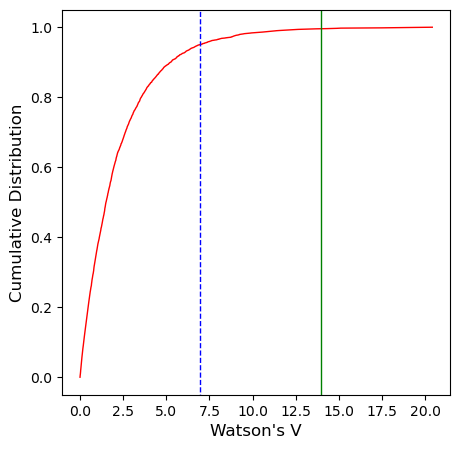

```
(0, 109.12107938638081, 74.54718328613993, '')
```

```python
directions_A=np.loadtxt('D_unbaked.txt', delimiter = ',')
directions_B=np.loadtxt('D_baked.txt', delimiter = ',')
plt.figure(1,(5,5))
ipmag.common_mean_watson(directions_A,directions_B,plot='yes')
```

# Failed Pseudo-Baked Contact Tests

## Site 4A

Firstly, the unbaked and baked data are loaded and named 'directions_A' and 'directions_B' respectively. We then calculate the fisher mean and alpha95 value (shown by the stars and large circles, respectively) and plot these along with the directional data for each specimen in red for baked directions and blue for unbaked directions.

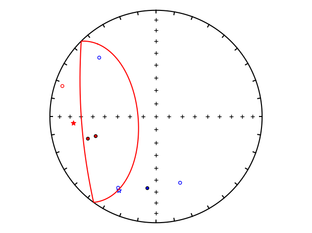

```python
directions_A=np.loadtxt('4A_unbaked.txt', delimiter = ',').transpose()
directions_B=np.loadtxt('4A_baked.txt', delimiter = ',').transpose()
decA=directions_A[0]
incA=directions_A[1]
decB=directions_B[0]
incB=directions_B[1]
#calculate Fisher mean and alpha 95
fisherA=ipmag.fisher_mean(dec=decA,inc=incA)
fisherB=ipmag.fisher_mean(dec=decB,inc=incB)
# plots stereonet of data
ipmag.plot_net(1)
directions_A=np.loadtxt('4A_unbaked.txt', delimiter = ',')
directions_B=np.loadtxt('4A_baked.txt', delimiter = ',')
ipmag.plot_di(di_block=directions_A,color='blue',edge='black')
ipmag.plot_di(di_block=directions_B,color='red',edge='black')
ipmag.plot_di_mean(dec=fisherA['dec'],inc=fisherA['inc'],a95=fisherA['alpha95'],\
                  marker='*',color='blue',markersize=50)
ipmag.plot_di_mean(dec=fisherB['dec'],inc=fisherB['inc'],a95=fisherB['alpha95'],\
                  marker='*',color='red',markersize=50)
```

## Site B

Firstly, the unbaked and baked data are loaded and named 'directions_A' and 'directions_B' respectively. We then calculate the fisher mean and alpha95 value (shown by the stars and large circles, respectively) and plot these along with the directional data for each specimen in red for baked directions and blue for unbaked directions.

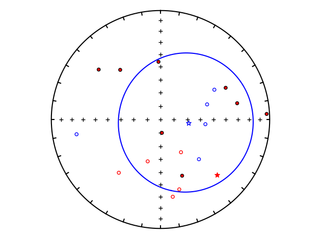

```python
directions_A=np.loadtxt('B_unbaked.txt', delimiter = ',').transpose()
directions_B=np.loadtxt('B_baked.txt', delimiter = ',').transpose()
decA=directions_A[0]
incA=directions_A[1]
decB=directions_B[0]
incB=directions_B[1]
#calculate Fisher mean and alpha 95
fisherA=ipmag.fisher_mean(dec=decA,inc=incA)
fisherB=ipmag.fisher_mean(dec=decB,inc=incB)
# plots stereonet of data
ipmag.plot_net(1)
directions_A=np.loadtxt('B_unbaked.txt', delimiter = ',')
directions_B=np.loadtxt('B_baked.txt', delimiter = ',')
ipmag.plot_di(di_block=directions_A,color='blue',edge='black')
ipmag.plot_di(di_block=directions_B,color='red',edge='black')
ipmag.plot_di_mean(dec=fisherA['dec'],inc=fisherA['inc'],a95=fisherA['alpha95'],\
                  marker='*',color='blue',markersize=50)
ipmag.plot_di_mean(dec=fisherB['dec'],inc=fisherB['inc'],a95=fisherB['alpha95'],\
                  marker='*',color='red',markersize=50)
```

```
Results of Watson V test:

Watson's V:           6.4
Critical value of V:  7.9
"Pass": Since V is less than Vcrit, the null hypothesis
that the two populations are drawn from distributions
that share a common mean direction can not be rejected.

M&M1990 classification:

Angle between data set means: 100.9
Critical angle for M&M1990:   114.9
The McFadden and McElhinny (1990) classification for
this test is: 'INDETERMINATE;
```

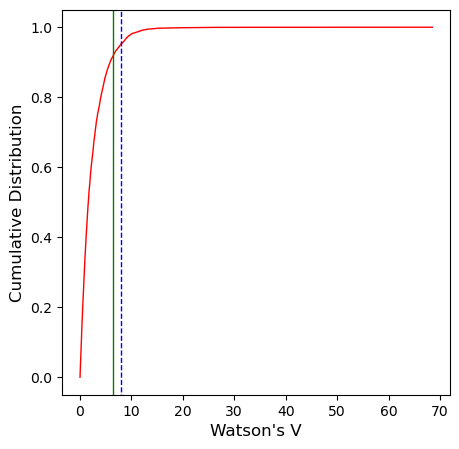

```
(1, 100.93722769086985, 114.8970896980433, 'indeterminate')
```

```python
directions_A=np.loadtxt('B_unbaked.txt', delimiter = ',')
directions_B=np.loadtxt('B_baked.txt', delimiter = ',')
plt.figure(1,(5,5))
ipmag.common_mean_watson(directions_A,directions_B,plot='yes')
```

# Fold Test

In this section we run a fold test on our passed pseudo baked contact tests from sites 8A/A, 6A and C. We take the basal bedding measurement from each site (note that this needs to be inputted into PMagPy as a dip and a dip direction, rather than a strike and dip) and use this to untilt our unbaked BIF directions to paleohorizontal.

## Unbaked Directions from 6A, 8A/A and C

The following commands take the unbaked BIF directions from sites 6A, 8A/A and C, and their basal bedding measurements and then gradually untilt them from -10 to 110% untilting.

The geographic stereonet shows the directions prior to tilt correction, and the tilt corrected stereonet shows the directions after 100% tilt correction.

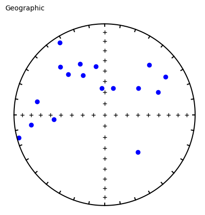

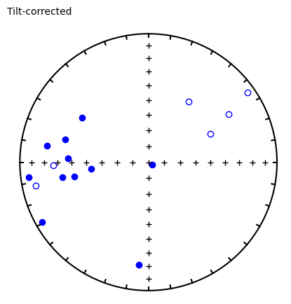

```
doing  1000  iterations...please be patient.....

tightest grouping of vectors obtained at (95% confidence bounds):
75 - 110 percent unfolding
range of all bootstrap samples:
-11  -  110 percent unfolding
```

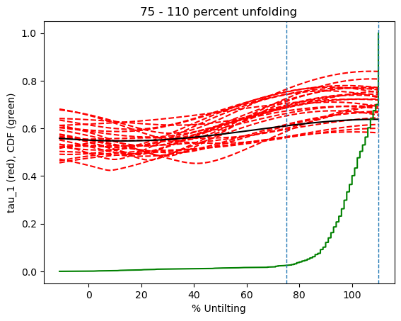

```python
fold_unbaked=np.loadtxt('Fold_test_unbaked.txt', delimiter = ',')
ipmag.bootstrap_fold_test(fold_unbaked,num_sims=1000, min_untilt=-11, max_untilt=111)
```

## Baked Directions from 6A, 8A/A and C

In this section we run a fold test on our passed pseudo baked contact tests from sites 8A/A, 6A and C. We take the basal bedding measurement from each site (note that this needs to be inputted into PMagPy as a dip and a dip direction, rather than a strike and dip) and use this to untilt our baked BIF directions to paleohorizontal.

The following commands take the baked BIF directions from sites 6A, 8A/A and C, and their basal bedding measurements and then gradually untilt them from -10 to 110% untilting.

The geographic stereonet shows the directions prior to tilt correction, and the tilt corrected stereonet shows the directions after 100% tilt correction.

$\tau_1$ is then calculated, which is a measure of how clustered the directions are regardless of their polarity. The green curve shows that clustering shows a strong increase between -5-45% untilting, indicating a negative fold test (i.e., the baked directions were acquired after the folding event, most likely during the emplacement of the Ameralik dykes).

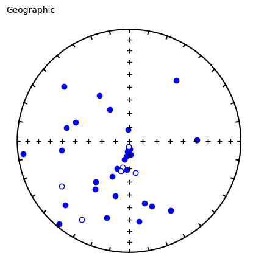

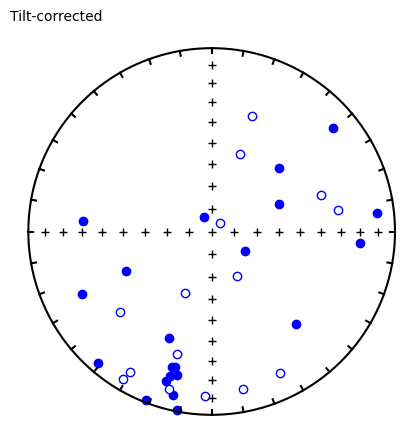

```
doing  1000  iterations...please be patient.....

tightest grouping of vectors obtained at (95% confidence bounds):
-6 - 110 percent unfolding
range of all bootstrap samples:
-11  -  110 percent unfolding
```

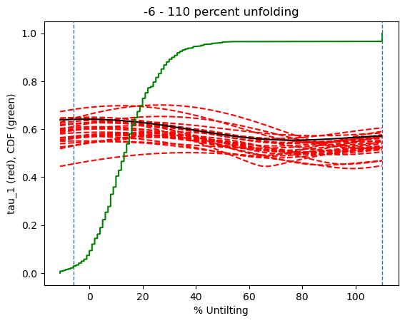

```python
fold_baked=np.loadtxt('Fold_test_baked.txt', delimiter = ',')
ipmag.bootstrap_fold_test(fold_baked,num_sims=1000, min_untilt=-11, max_untilt=111)
```

# Tilt-corrected Fold Test

The following uses the trend and plunge of the fold axis (54/181) recovered from structural data in the northernmost part of the area. Below, we show our fold test after un-tilting the fold axis to horizontal.

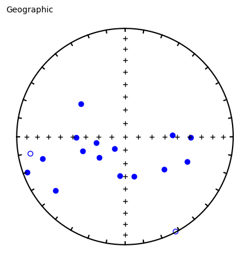

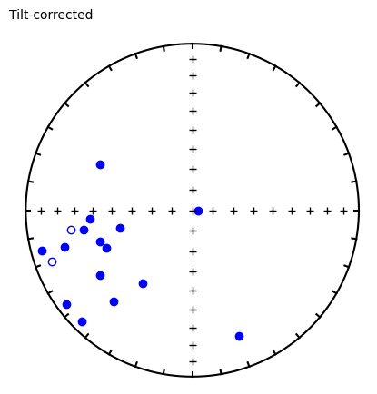

```
doing  1000  iterations...please be patient.....

tightest grouping of vectors obtained at (95% confidence bounds):
81 - 110 percent unfolding
range of all bootstrap samples:
-11  -  110 percent unfolding
```

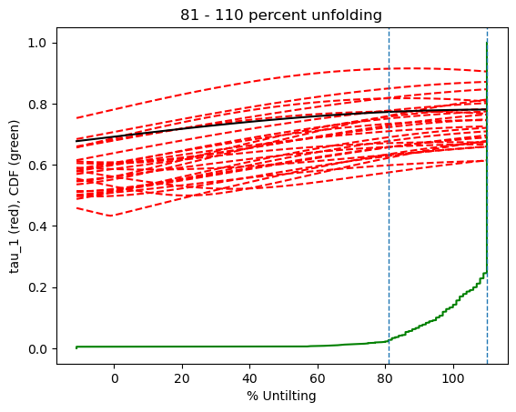

```python
fold_unbaked=np.loadtxt('fold_test_unbaked_TC.txt', delimiter = ',')
ipmag.bootstrap_fold_test(fold_unbaked,num_sims=1000, min_untilt=-11, max_untilt=111)
```

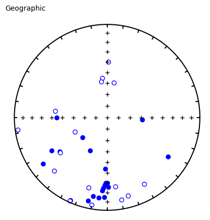

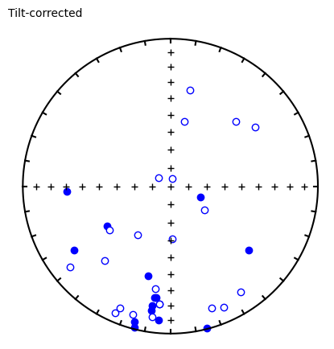

```
doing  1000  iterations...please be patient.....

tightest grouping of vectors obtained at (95% confidence bounds):
-11 - 92 percent unfolding
range of all bootstrap samples:
-11  -  110 percent unfolding
```

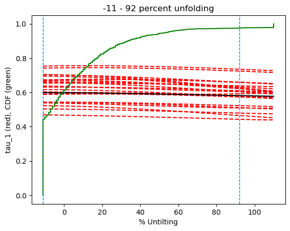

```python
fold_unbaked=np.loadtxt('fold_test_baked_TC.txt', delimiter = ',')
ipmag.bootstrap_fold_test(fold_unbaked,num_sims=1000, min_untilt=-11, max_untilt=111)
```